# Maternal Health Coverage Analysis

Coverage Gaps Between On-Track and Off-Track Countries for SDG 3.1

Report Generated: July 27, 2025

## Executive Summary

**Key Finding:** Significant maternal health coverage gaps exist between countries on-track and off-track to meet SDG 3.1 targets, with population-weighted coverage differences of **29.3 percentage points** for antenatal care and **22.8 percentage points** for skilled birth attendance.

### Countries Analyzed

152

102 on-track, 50 off-track

### Total Births (2022)

60.6M

12.2M on-track, 48.4M off-track

### ANC4+ Coverage Gap

29.3pp

84.4% vs 55.2%

### SBA Coverage Gap

22.8pp

96.4% vs 73.6%

**Critical Implications:** The coverage gaps represent millions of women and newborns lacking access to essential maternal health services. Off-track countries, which account for 48.4 million births annually (79.9% of global births), require immediate, targeted interventions to achieve universal health coverage and reduce maternal mortality.

## Methodology

### Data Sources

- **Health Coverage Data:** WHO Global Health Observatory (GHO) database, 2018-2022
- **Demographic Data:** UN World Population Prospects 2022 Revision
- **SDG Progress Classification:** WHO/UNICEF/UNFPA/World Bank/UNDESA maternal mortality tracking

### Indicators Analyzed

#### Antenatal Care Coverage (ANC4+)

Percentage of women aged 15-49 years with a live birth who received antenatal care four or more times during pregnancy, as recommended by WHO guidelines.

#### Skilled Birth Attendance (SBA)

Percentage of births attended by skilled health personnel (doctors, nurses, or midwives) trained in providing lifesaving obstetric care.

### Analysis Approach

1. **Country Classification:** Countries categorized as "on-track" or "off-track" based on progress toward SDG 3.1 target (reducing maternal mortality ratio to less than 70 per 100,000 live births by 2030)
2. **Population Weighting:** Coverage percentages weighted by annual births (2022) to reflect population-level impact
3. **Gap Analysis:** Calculated absolute differences in coverage between on-track and off-track countries
4. **Data Quality:** Analysis limited to countries with available data for each indicator

### Statistical Methods

Population-weighted coverage calculated as:

Weighted Coverage = Σ(Coverage<sub>i</sub> × Births<sub>i</sub>) / Σ(Births<sub>i</sub>)

where i represents individual countries within each track status group.

## Results

### Coverage Comparison Visualization

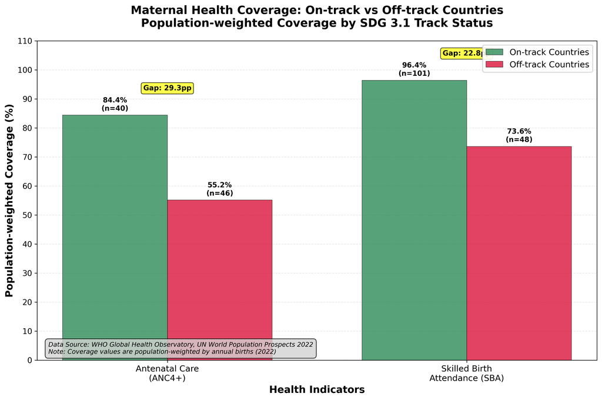

### Summary Statistics Table

| Indicator | Track Status | Countries (n) | Total Births | Weighted Coverage | Min Coverage | Max Coverage | Median Coverage |
| --- | --- | --- | --- | --- | --- | --- | --- |
| Antenatal Care (ANC4+) | On-Track | 40 | 9.6M | 84.4% | 53.5% | 99.9% | 88.5% |
| Antenatal Care (ANC4+) | Off-Track | 46 | 47.5M | 55.2% | 24.4% | 97.6% | 62.0% |
| Skilled Birth Attendance (SBA) | On-Track | 101 | 11.9M | 96.4% | 71.5% | 100.0% | 99.1% |
| Skilled Birth Attendance (SBA) | Off-Track | 48 | 47.5M | 73.6% | 31.9% | 100.0% | 83.9% |

### Coverage Gap Analysis

#### Antenatal Care (ANC4+)

**Coverage Gap:** 29.3 percentage points

**Relative Difference:** 53.1% higher coverage in on-track countries

**Affected Population:** Approximately 14.2 million additional women could receive adequate antenatal care if off-track countries achieved on-track coverage levels

#### Skilled Birth Attendance (SBA)

**Coverage Gap:** 22.8 percentage points

**Relative Difference:** 31.0% higher coverage in on-track countries

**Affected Population:** Approximately 11.0 million additional births could be attended by skilled personnel if off-track countries achieved on-track coverage levels

## Key Findings and Interpretation

### Primary Findings

#### 1. Substantial Coverage Disparities

Off-track countries demonstrate significantly lower maternal health service coverage across both indicators. The 29.3 percentage point gap in ANC4+ coverage and 22.8 percentage point gap in SBA coverage represent substantial disparities that directly impact maternal and newborn health outcomes.

#### 2. Population-Level Impact

Off-track countries account for 48.4 million births annually (79.9% of the global total), meaning coverage gaps affect a substantial portion of the world's pregnant women and newborns. This represents approximately 14.2 million women lacking adequate antenatal care and 11.0 million births without skilled attendance.

#### 3. Service-Specific Patterns

**Antenatal Care:** Shows the larger coverage gap (29.3pp), with on-track countries achieving 84.4% coverage compared to 55.2% in off-track countries. This suggests particular challenges in establishing comprehensive prenatal care systems.

**Skilled Birth Attendance:** Demonstrates a 22.8pp gap, with generally higher overall coverage levels (96.4% vs 73.6%), indicating that delivery care may be more prioritized than comprehensive antenatal services.

#### 4. Countries Requiring Urgent Attention

**Lowest ANC4+ Coverage:** Somalia (24.4%), Afghanistan (27.6%), Senegal (29.2%)

**Lowest SBA Coverage:** Somalia (31.9%), South Sudan (39.7%), Central African Republic (40.3%)

These countries represent priority targets for immediate intervention and support.

### Interpretation in Context

The observed coverage gaps align with broader patterns of health system capacity and maternal mortality outcomes. Countries off-track for SDG 3.1 face multiple, interconnected challenges including:

- **Health System Capacity:** Limited infrastructure, workforce shortages, and inadequate supply chains
- **Geographic Barriers:** Rural populations with limited access to health facilities
- **Economic Constraints:** Both at health system and household levels
- **Social Determinants:** Gender inequality, education levels, and cultural factors affecting care-seeking

The larger gap in antenatal care compared to skilled birth attendance suggests that while emergency delivery care receives priority attention, comprehensive prenatal care systems require additional focus and investment.

## Policy Implications

### Immediate Priorities

Given the larger coverage gap in ANC4+, specific attention should be paid to establishing comprehensive antenatal care programs that ensure women receive the recommended minimum of four visits with quality care.

#### 3. Integrated Service Delivery

Develop integrated maternal health service delivery models that combine antenatal care, skilled birth attendance, and postnatal care to maximize efficiency and coverage.

### Strategic Approaches

#### Health System Strengthening

- Expand health workforce training and deployment, particularly in rural areas
- Improve health facility infrastructure and equipment
- Strengthen supply chain management for essential medicines and supplies
- Implement quality improvement programs for maternal health services

#### Financial Protection and Access

- Remove financial barriers through universal health coverage mechanisms
- Implement targeted subsidies or voucher programs for maternal health services
- Address transportation and geographic barriers to care
- Develop community-based service delivery models

#### Data and Monitoring Systems

- Strengthen health information systems for real-time monitoring
- Improve data quality and coverage for maternal health indicators
- Establish accountability mechanisms for coverage targets
- Support evidence-based decision making at all levels

### Global and Regional Coordination

The scale of the coverage gaps requires coordinated international action:

- **Multilateral Support:** Increased funding through global health initiatives and development banks
- **Technical Assistance:** Knowledge sharing and capacity building between countries
- **Regional Platforms:** Leverage regional health organizations for peer learning and coordination
- **Private Sector Engagement:** Innovative partnerships to expand service delivery and financing

#### Urgency of Action

With only 5 years remaining to achieve SDG 3.1 by 2030, immediate and sustained action is required. The current coverage gaps, if left unaddressed, will result in preventable maternal and newborn deaths and perpetuate health inequities globally.

## Limitations and Assumptions

### Data Limitations

#### Data Availability and Coverage

- ANC4+ data available for 86 countries (40 on-track, 46 off-track)
- SBA data available for 149 countries (101 on-track, 48 off-track)
- Missing data may bias results if non-reporting countries have systematically different coverage patterns
- Some countries have data from different years within the 2018-2022 period

#### Indicator Definitions and Measurement

- Coverage indicators reflect service utilization but not necessarily quality of care
- Skilled birth attendance definition may vary across countries in terms of training standards
- Self-reported data in household surveys may be subject to recall bias
- Administrative data may have completeness and accuracy issues

#### Population Weighting Methodology

- Birth data from UN World Population Prospects may not perfectly align with health survey periods
- Population weighting assumes uniform coverage within countries, which may not reflect subnational variations
- Negative birth values in some developed countries (indicating population decline) handled as absolute values for weighting

### Methodological Assumptions

#### Country Classification

Countries classified as "on-track" or "off-track" based on maternal mortality trends and projections. This classification may not capture recent changes in trajectory or account for data quality issues in mortality estimates.

#### Causal Relationships

Analysis identifies associations between track status and coverage but does not establish causal relationships. Multiple factors contribute to both maternal mortality outcomes and service coverage levels.

#### Temporal Alignment

Assumes that coverage data from 2018-2022 period reflects current service delivery capacity and is representative of recent performance.

### Interpretation Considerations

#### Context-Specific Factors

Coverage gaps reflect complex interactions of health system capacity, socioeconomic factors, geographic challenges, and policy environments. Simple comparisons may not capture the full complexity of country-specific contexts.

#### Quality vs. Quantity

Higher coverage does not automatically translate to better health outcomes if service quality is poor. Quality of care indicators would provide additional insights but are not included in this analysis.

#### Equity Considerations

National-level coverage figures may mask significant within-country inequities by wealth, education, geographic location, and other social determinants of health.

#### Recommendations for Future Analysis

- Include service quality indicators alongside coverage measures
- Conduct subnational analysis to identify within-country disparities
- Incorporate trend analysis to assess progress over time
- Add cost-effectiveness analysis of different intervention approaches
- Include additional maternal health indicators (e.g., postnatal care, family planning)

## About This Report

This report was generated as part of a comprehensive analysis of maternal health coverage gaps between countries on-track and off-track to meet Sustainable Development Goal 3.1. The analysis combines data from WHO Global Health Observatory, UN World Population Prospects, and maternal mortality tracking systems to provide evidence-based insights for policy and program development.

**For more information or technical details about this analysis, please contact the Data Analysis Team.**

© 2025 Maternal Health Coverage Analysis Project | Generated on July 27, 2025